# Calculating Walking and cycling trips impedance function- 2015

# Active-transport walking and cycling behaviour in Canada

## Data and Method

Data on walking and cycling trips to different destinations was derived from Canada’s General Social Survey (GSS) from 1986 to 2015. GSS is a social trends survey in order to monitor changes in the living conditions and well-being of Canadians and to provide information on specific social policy issues. one of the important information of GSS is about Time-use surveys. This survey collects information on all human activities and can therefore inform a broad range of policies. Statistics Canada has been conducting time-use surveys since 1986 at approximately five- to seven- year intervals, most recently in 2015.The GSS on time use employs a retrospective 24-hour time diary to collect information on respondents’ participation in, and time spent on, a wide variety of day-to-day activities. In addition, information is collected on the location where these activities occurred (e.g., at home, at work, etc.).in addition, This dataset contains travel time data of Many of the Census Metropolitan Areas (CMAs) and non-CMA areas all over Canada. CMAs are including St. John’s, Halifax, Saint John, Montreal, Quebec City, Toronto, Ottawa, Hamilton, Winnipeg, Regina, Saskatoon, Calgary, Edmonton, and Vancouver. and the non-CMA areas of each of the ten provinces were also grouped to form ten more strata.

walking and cycling data are categorized based on the three different destinations such as home, school and work, and others’ homes. every episode includes, the start and end time of each event, duration, weight, and concurrent contextual information, such as the location of the activities (e.g., home, work, schools,…).

# Result

First load all of the libraries

Here, we are loading all the primary files of the GSS dataset to create our database for analysis.

### Calculating impedance function for walking in 2015

using a skew vs. kurtois graph to descriptive statistics of data

```r
count <- sum(walking_2015$DURATION > 100)
print (count)
```

```
[1] 25
```

```r
walking_2015 <- walking_2015 %>% filter(DURATION <= 100)
summary(walking_2015$DURATION)
```

```
   Min. 1st Qu.  Median    Mean 3rd Qu.    Max.
   5.00   10.00   10.00   16.32   20.00   95.00
```

```
summary statistics
------
min:  5   max:  95
median:  10
mean:  16.31641
estimated sd:  13.81231
estimated skewness:  2.492389
estimated kurtosis:  10.67251
```

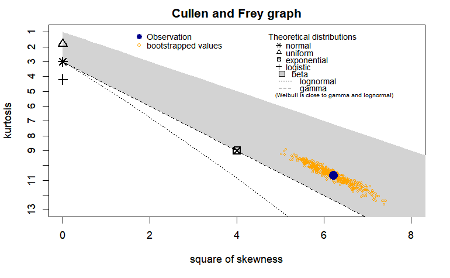

```r
# creating a skew vs. kurtois graph for walking 2015

descdist(walking_2015$DURATION %>% unlist() %>% as.numeric(), discrete=FALSE, boot=500)
```

As shown in the Cullen and Frey graph, we see that gamma and exponential will likely be the best fit according to the graph above. Then we compare these models to find the best model.

```r
# Based on the skew vs. kurtois graph the best distribution

#Calculating gamma distribution
gamma_w_2015_ <- fitdistrplus::fitdist(data=walking_2015$DURATION%>% unlist() %>% as.numeric(), "gamma", method="mle", optim.method="Nelder-Mead", weights = round(walking_2015$WGHT_EPI))
fit_dgamma <- data.frame(f = dgamma(walking_2015$DURATION, shape = gamma_w_2015_$estimate[1], rate = gamma_w_2015_$estimate[2]), x = walking_2015$DURATION, type = "Gamma")

summary(gamma_w_2015_)
```

```
Fitting of the distribution ' gamma ' by maximum likelihood
Parameters :
```

|  | estimate | Std. Error |
| --- | --- | --- |
| shape | 2.2632303 | 1.307910e-03 |
| rate | 0.1395914 | 9.027038e-05 |

```
Loglikelihood:  -19039590   AIC:  38079183   BIC:  38079195
Correlation matrix:
         shape     rate
shape 1.000000 0.893563
rate  0.893563 1.000000
```

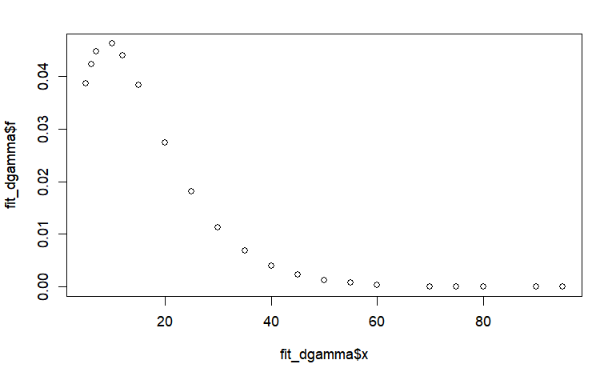

```r
plot(x= fit_dgamma$x, y=fit_dgamma$f)
```

```r
#Calculating exponential distribution
exp_w_2015_ <- fitdistrplus::fitdist(data=walking_2015$DURATION%>% unlist() %>% as.numeric(), "exp", method="mle", optim.method="Nelder-Mead", weights = round(walking_2015$WGHT_EPI))
summary(exp_w_2015_)
```

```
Fitting of the distribution ' exp ' by maximum likelihood
Parameters :
```

|  | estimate | Std. Error |
| --- | --- | --- |
| rate | 0.06167104 | 2.69294e-05 |

```
Loglikelihood:  -19844425   AIC:  39688852   BIC:  39688858
```

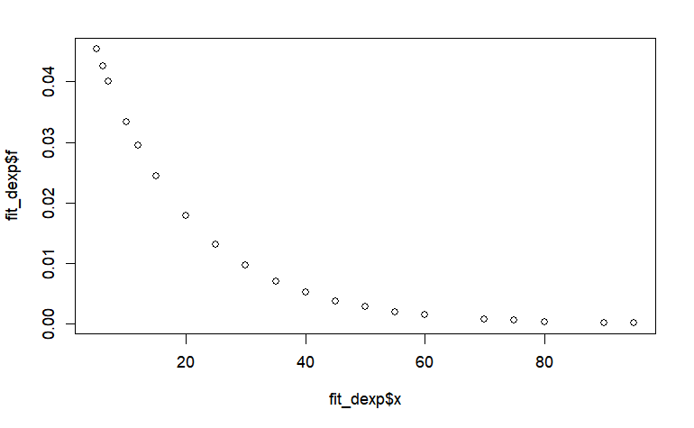

```r
fit_dexp <- data.frame(f = dexp(walking_2015$DURATION,  exp_w_2015_$estimate[1]),
                       x = walking_2015$DURATION, type = "exp")

plot(x = fit_dexp$x, y = fit_dexp$f)
```

```r
#plot <- ggplot(walking_2015, aes(x = DURATION, y =f)) +
  #geom_line(aes(group = 1)) +  # Ensure there's a group aesthetic for line plots
  #labs(title = "Line Chart", x = "X Axis Label", y = "Y Axis Label") +
  #theme_minimal()

#print(plot)
```

Now let’s compare these models AIC and BIC to see which fits the walk data best:

```r
#comparing these models AIC and BIC to see which fits the walk data best:
broom::glance(MASS::fitdistr(walking_2015$DURATION%>% unlist() %>% as.numeric(),"gamma"))
```

| logLik | AIC | BIC | nobs |
| --- | --- | --- | --- |
| -10220.71 | 20445.42 | 20457.29 | 2797 |

```r
broom::glance(MASS::fitdistr(walking_2015$DURATION%>% unlist() %>% as.numeric(),"exponential"))
```

| logLik | AIC | BIC | nobs |
| --- | --- | --- | --- |
| -10606.7 | 21215.41 | 21221.34 | 2797 |

So, gamma has largest logLik and the smallest AIC and BIC. we will pick gamma function for walking trips in 2015!

```r
walking_2015_gamma <- gamma_w_2015_
walking_2015 <- walking_2015 %>%
 mutate(f = dgamma(DURATION, walking_2015_gamma$estimate["shape"], walking_2015_gamma$estimate["rate"]))
summary(walking_2015$f)
```

```
     Min.   1st Qu.    Median      Mean   3rd Qu.      Max.
5.570e-06 2.742e-02 3.863e-02 3.444e-02 4.614e-02 4.614e-02
```

### Calculating impedance function for walking in 2015 based on different purposes

###Destination : Walking - Home (300),2015

using a skew vs. kurtois graph to descriptive statistics of data

```
summary statistics
------
min:  5   max:  95
median:  10
mean:  17.58959
estimated sd:  15.33923
estimated skewness:  2.34156
estimated kurtosis:  9.383401
```

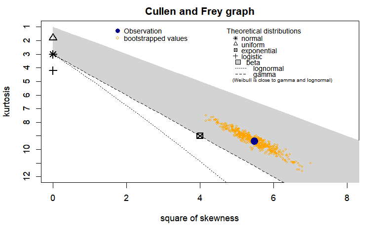

```r
# creating a skew vs. kurtois graph for walking 2015

# Filter the data based on the "destination" column
 w_300_2015 <- walking_2015 %>%
  filter(destination == "300")
descdist(w_300_2015$DURATION %>% unlist() %>% as.numeric(), discrete=FALSE, boot=500)
```

As shown in the Cullen and Frey graph, we see that gamma, weibull and exponential will likely be the best fit according to the graph above. Then we compare these models to find the best model.

```r
# Based on the skew vs. kurtois graph the best distribution

#Calculating gamma distribution
gamma_w300_2015_ <- fitdistrplus::fitdist(data=w_300_2015$DURATION%>% unlist() %>% as.numeric(), "gamma", method="mle", optim.method="Nelder-Mead", weights = round(w_300_2015$WGHT_EPI))
fit_dgamma_w30015 <- data.frame(f_300 = dgamma(w_300_2015$DURATION, shape = gamma_w300_2015_$estimate[1], rate = gamma_w300_2015_$estimate[2]), x = w_300_2015$DURATION, type = "Gamma")

summary(gamma_w300_2015_)
```

```
Fitting of the distribution ' gamma ' by maximum likelihood
Parameters :
```

|  | estimate | Std. Error |
| --- | --- | --- |
| shape | 2.1072578 | 0.0017986073 |
| rate | 0.1223731 | 0.0001178546 |

```
Loglikelihood:  -8849423   AIC:  17698850   BIC:  17698860
Correlation matrix:
          shape      rate
shape 1.0000000 0.8861557
rate  0.8861557 1.0000000
```

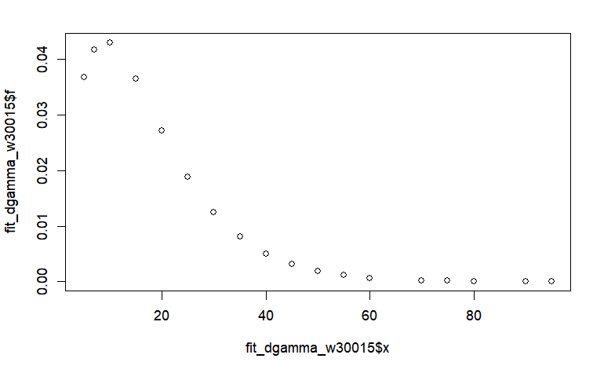

```r
plot(x= fit_dgamma_w30015$x, y=fit_dgamma_w30015$f)
```

```r
#Calculating weibull distribution
weibull_w300_2015_ <- fitdistrplus::fitdist(data=w_300_2015$DURATION%>% unlist() %>% as.numeric(), "weibull", method="mle", optim.method="Nelder-Mead", weights = round(w_300_2015$WGHT_EPI))
summary(weibull_w300_2015_)
```

```
Fitting of the distribution ' weibull ' by maximum likelihood
Parameters :
```

|  | estimate | Std. Error |
| --- | --- | --- |
| shape | 1.358231 | 0.0006144312 |
| scale | 19.024038 | 0.0096495216 |

```
Loglikelihood:  -8973610   AIC:  17947223   BIC:  17947233
Correlation matrix:
        shape   scale
shape 1.00000 0.33953
scale 0.33953 1.00000
```

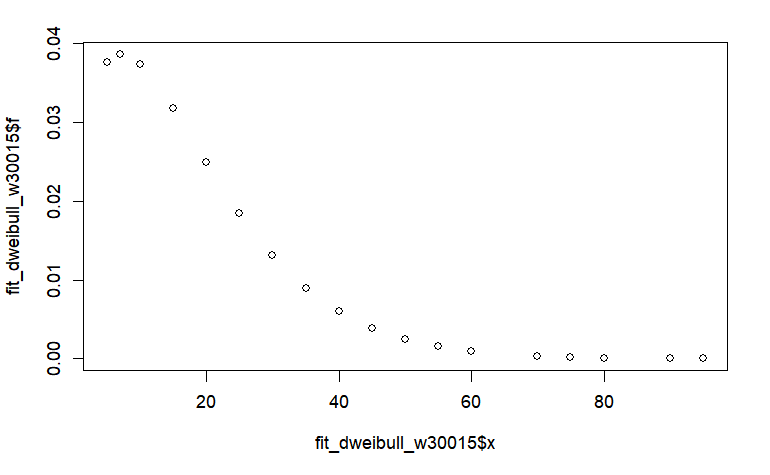

```r
fit_dweibull_w30015 <- data.frame(f = dweibull(w_300_2015$DURATION, shape = weibull_w300_2015_$estimate[1], scale = weibull_w300_2015_$estimate[2]), x = w_300_2015$DURATION, type = "weibull")

plot(x= fit_dweibull_w30015$x, y=fit_dweibull_w30015$f)
```

```r
#Calculating exponential distribution
exp_w300_2015_ <- fitdistrplus::fitdist(data=w_300_2015$DURATION%>% unlist() %>% as.numeric(), "exp", method="mle", optim.method="Nelder-Mead", weights = round(w_300_2015$WGHT_EPI))
summary(exp_w300_2015_)
```

```
Fitting of the distribution ' exp ' by maximum likelihood
Parameters :
```

|  | estimate | Std. Error |
| --- | --- | --- |
| rate | 0.05807325 | 3.761315e-05 |

```
Loglikelihood:  -9162499   AIC:  18325001   BIC:  18325006
```

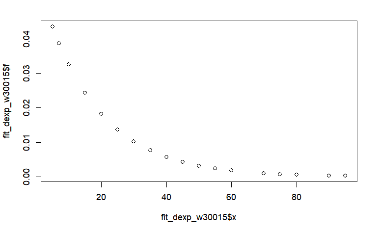

```r
# Get the estimated rate parameter from the fitted distribution
rate_estimate <- exp_w300_2015_$estimate[1]

# Create a data frame for the fitted exponential distribution
fit_dexp_w30015 <- data.frame(f = dexp(w_300_2015$DURATION, rate = rate_estimate),
                       x = w_300_2015$DURATION, type = "exp")

# Plot the fitted exponential distribution
plot(x = fit_dexp_w30015$x, y = fit_dexp_w30015$f)
```

Now let’s compare these models AIC and BIC to see which fits the walk data best:

```r
#comparing these models AIC and BIC to see which fits the walk data best:
broom::glance(MASS::fitdistr(w_300_2015$DURATION%>% unlist() %>% as.numeric(),"gamma"))
```

| logLik | AIC | BIC | nobs |
| --- | --- | --- | --- |
| -4899.434 | 9802.868 | 9813.217 | 1306 |

```r
broom::glance(MASS::fitdistr(w_300_2015$DURATION%>% unlist() %>% as.numeric(),"weibull"))
```

| logLik | AIC | BIC | nobs |
| --- | --- | --- | --- |
| -4959.63 | 9923.26 | 9933.61 | 1306 |

```r
broom::glance(MASS::fitdistr(w_300_2015$DURATION%>% unlist() %>% as.numeric(),"exponential"))
```

| logLik | AIC | BIC | nobs |
| --- | --- | --- | --- |
| -5050.703 | 10103.41 | 10108.58 | 1306 |

So, gamma has largest logLik and the smallest AIC and BIC. we will pick gamma function for walking trips in 2015!

```r
walking_30015_gamma <- gamma_w300_2015_
w_300_2015 <- w_300_2015 %>%
 mutate(f_300 = dgamma(DURATION, walking_30015_gamma$estimate["shape"], walking_30015_gamma$estimate["rate"]))
summary(w_300_2015$f_300)
```

```
     Min.   1st Qu.    Median      Mean   3rd Qu.      Max.
1.575e-05 2.716e-02 3.668e-02 3.171e-02 4.286e-02 4.286e-02
```

###Destination : Walking - work or school (301), 2015 using a skew vs. kurtois graph to descriptive statistics of data

```
summary statistics
------
min:  5   max:  80
median:  10
mean:  15.68134
estimated sd:  11.35778
estimated skewness:  1.969036
estimated kurtosis:  7.858696
```

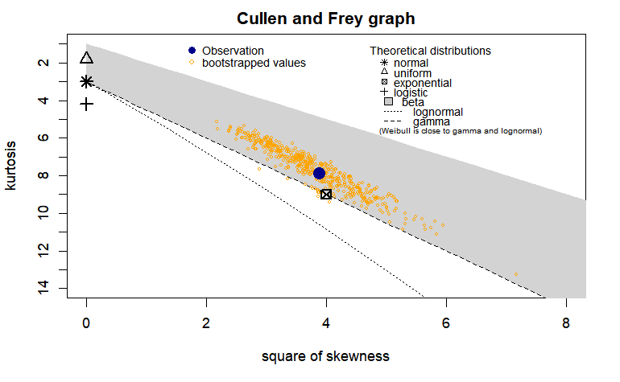

```r
# creating a skew vs. kurtois graph for walking 2015

# Filter the data based on the "destination" column
 w_301_2015 <- walking_2015 %>%
  filter(destination == "301")
descdist(w_301_2015$DURATION %>% unlist() %>% as.numeric(), discrete=FALSE, boot=500)
```

As shown in the Cullen and Frey graph, we see that gamma, weibull, lognormal and exponential will likely be the best fit according to the graph above. Then we compare these models to find the best model.

```r
# Based on the skew vs. kurtois graph the best distribution

#Calculating gamma distribution

gamma_w301_2015_ <- fitdistrplus::fitdist(data=w_301_2015$DURATION%>% unlist() %>% as.numeric(), "gamma", method="mle", optim.method="Nelder-Mead", weights = round(w_301_2015$WGHT_EPI))
fit_dgamma_30115 <- data.frame(f = dgamma(w_301_2015$DURATION, shape = gamma_w301_2015_$estimate[1], rate = gamma_w301_2015_$estimate[2]), x = w_301_2015$DURATION, type = "Gamma")

summary(gamma_w301_2015_)
```

```
Fitting of the distribution ' gamma ' by maximum likelihood
Parameters :
```

|  | estimate | Std. Error |
| --- | --- | --- |
| shape | 2.7437291 | 0.003578225 |
| rate | 0.1757991 | 0.000251543 |

```
Loglikelihood:  -3709579   AIC:  7419161   BIC:  7419170
Correlation matrix:
          shape      rate
shape 1.0000000 0.9113969
rate  0.9113969 1.0000000
```

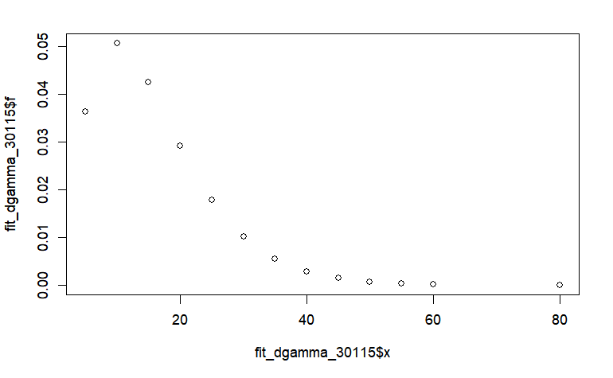

```r
plot(x= fit_dgamma_30115$x, y=fit_dgamma_30115$f)
```

```r
#Calculating weibull distribution
weibull_w301_2015_ <- fitdistrplus::fitdist(data=w_301_2015$DURATION%>% unlist() %>% as.numeric(), "weibull", method="mle", optim.method="Nelder-Mead", weights = round(w_301_2015$WGHT_EPI))
summary(weibull_w301_2015_)
```

```
Fitting of the distribution ' weibull ' by maximum likelihood
Parameters :
```

|  | estimate | Std. Error |
| --- | --- | --- |
| shape | 1.569099 | 0.00107368 |
| scale | 17.554826 | 0.01159648 |

```
Loglikelihood:  -3775089   AIC:  7550182   BIC:  7550191
Correlation matrix:
          shape     scale
shape 1.0000000 0.3384184
scale 0.3384184 1.0000000
```

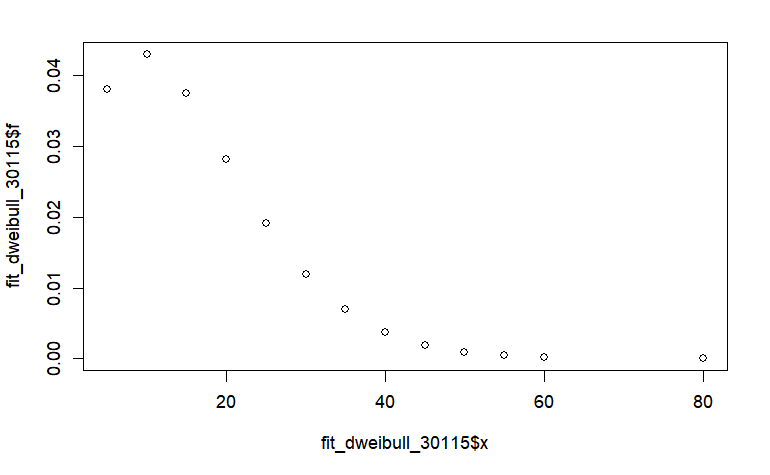

```r
fit_dweibull_30115 <- data.frame(f = dweibull(w_301_2015$DURATION, shape = weibull_w301_2015_$estimate[1], scale = weibull_w301_2015_$estimate[2]), x = w_301_2015$DURATION, type = "weibull")

plot(x= fit_dweibull_30115$x, y=fit_dweibull_30115$f)
```

```r
#Calculating exponential distribution
exp_w301_2015_ <- fitdistrplus::fitdist(data=w_301_2015$DURATION%>% unlist() %>% as.numeric(), "exp", method="mle", optim.method="Nelder-Mead", weights = round(w_301_2015$WGHT_EPI))
summary(exp_w301_2015_)
```

```
Fitting of the distribution ' exp ' by maximum likelihood
Parameters :
```

|  | estimate | Std. Error |
| --- | --- | --- |
| rate | 0.06406898 | 6.247726e-05 |

```
Loglikelihood:  -3939418   AIC:  7878838   BIC:  7878843
```

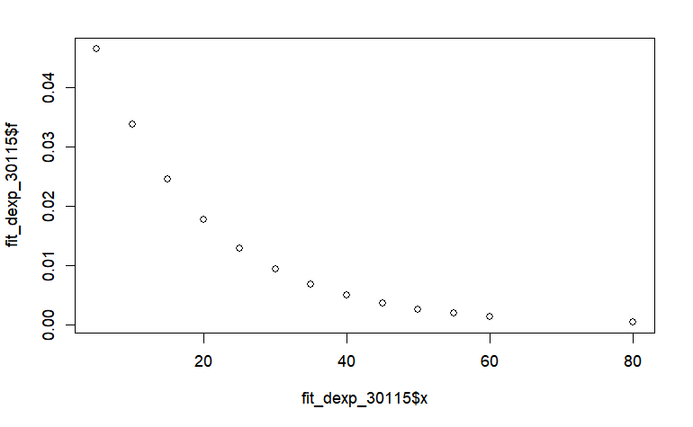

```r
# Get the estimated rate parameter from the fitted distribution
rate_estimate <- exp_w301_2015_$estimate[1]

# Create a data frame for the fitted exponential distribution
fit_dexp_30115 <- data.frame(f = dexp(w_301_2015$DURATION, rate = rate_estimate),
                       x = w_301_2015$DURATION, type = "exp")

# Plot the fitted exponential distribution
plot(x = fit_dexp_30115$x, y = fit_dexp_30115$f)
```

Now let’s compare these models AIC and BIC to see which fits the walk data best:

```r
#comparing these models AIC and BIC to see which fits the walk data best:
broom::glance(MASS::fitdistr(w_301_2015$DURATION%>% unlist() %>% as.numeric(),"gamma"))
```

| logLik | AIC | BIC | nobs |
| --- | --- | --- | --- |
| -1696.998 | 3397.996 | 3406.331 | 477 |

```r
broom::glance(MASS::fitdistr(w_301_2015$DURATION%>% unlist() %>% as.numeric(),"weibull"))
```

| logLik | AIC | BIC | nobs |
| --- | --- | --- | --- |
| -1721.973 | 3447.946 | 3456.281 | 477 |

```r
broom::glance(MASS::fitdistr(w_301_2015$DURATION%>% unlist() %>% as.numeric(),"exponential"))
```

| logLik | AIC | BIC | nobs |
| --- | --- | --- | --- |
| -1789.929 | 3581.858 | 3586.025 | 477 |

So, gamma has largest logLik and the smallest AIC and BIC. we will pick gamma function for walking trips in 2015!(301)

```r
walking_30115_gamma <- gamma_w301_2015_
w_301_2015 <- w_301_2015 %>%
 mutate(f_301 = dgamma(DURATION, walking_30115_gamma$estimate["shape"], walking_30115_gamma$estimate["rate"]))
summary(w_301_2015$f_301)
```

```
     Min.   1st Qu.    Median      Mean   3rd Qu.      Max.
8.610e-06 2.924e-02 4.265e-02 3.677e-02 5.065e-02 5.065e-02
```

###Destination : Business (302) using a skew vs. kurtois graph to descriptive statistics of data

```r
# creating a skew vs. kurtois graph for walking 2015 _ Business destination

# Filter the data based on the "destination" column
 w_302_2015 <- walking_2015 %>%
  filter(destination == "302")
summary(w_302_2015)
```

```
     PUMFID         WGHT_EPI           DDAY          STARTIME         ENDTIME          STARTMIN          ENDMIN
 Min.   :12136   Min.   : 603.6   Min.   :2.000   Min.   : 800.0   Min.   : 810.0   Min.   : 480.0   Min.   : 490.0
 1st Qu.:13186   1st Qu.:1266.4   1st Qu.:2.500   1st Qu.: 817.5   1st Qu.: 832.5   1st Qu.: 497.5   1st Qu.: 512.5
 Median :15342   Median :1859.6   Median :4.000   Median :1350.0   Median :1400.0   Median : 830.0   Median : 840.0
 Mean   :16456   Mean   :1984.4   Mean   :3.857   Mean   :1406.4   Mean   :1425.0   Mean   : 852.1   Mean   : 865.0
 3rd Qu.:19466   3rd Qu.:2533.7   3rd Qu.:4.500   3rd Qu.:1865.0   3rd Qu.:1882.5   3rd Qu.:1125.0   3rd Qu.:1142.5
 Max.   :22407   Max.   :3827.7   Max.   :7.000   Max.   :2330.0   Max.   :2335.0   Max.   :1410.0   Max.   :1415.0
    DURATION        LOCATION       origin       destination      dest               orig                YEAR
 Min.   : 5.00   Min.   :315   Min.   :300.0   Min.   :302   Length:7           Length:7           Min.   :2015
 1st Qu.: 5.00   1st Qu.:315   1st Qu.:300.5   1st Qu.:302   Class :character   Class :character   1st Qu.:2015
 Median :10.00   Median :315   Median :301.0   Median :302   Mode  :character   Mode  :character   Median :2015
 Mean   :12.86   Mean   :315   Mean   :303.1   Mean   :302                                         Mean   :2015
 3rd Qu.:17.50   3rd Qu.:315   3rd Qu.:305.5   3rd Qu.:302                                         3rd Qu.:2015
 Max.   :30.00   Max.   :315   Max.   :309.0   Max.   :302                                         Max.   :2015
     MODE                 f
 Length:7           Min.   :0.01133
 Class :character   1st Qu.:0.02836
 Mode  :character   Median :0.03863
                    Mean   :0.03394
                    3rd Qu.:0.04238
                    Max.   :0.04614
```

```
summary statistics
------
min:  5   max:  30
median:  10
mean:  12.85714
estimated sd:  10.35098
estimated skewness:  1.120666
estimated kurtosis:  2.464889
```

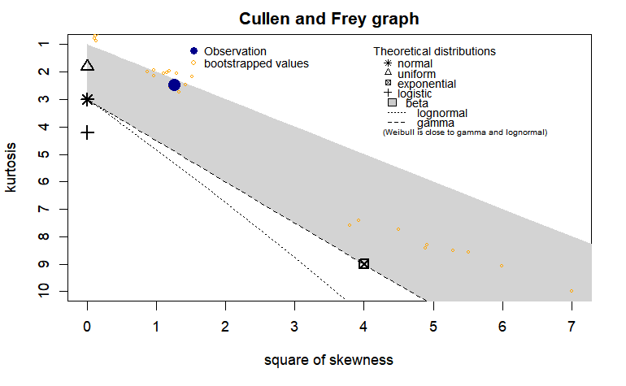

```r
descdist(w_302_2015$DURATION %>% unlist() %>% as.numeric(), discrete=FALSE, boot=100)
```

```r
# Based on the skew vs. kurtois graph the best distribution

#Calculating pois distribution
pois_w302_2015_ <- fitdistrplus::fitdist(data=w_302_2015$DURATION%>% unlist() %>% as.numeric(), "pois", method="mle", optim.method="Nelder-Mead", weights = round(w_302_2015$WGHT_EPI))
fit_dpois_30215 <- data.frame(f = dpois(w_302_2015$DURATION, lambda = pois_w302_2015_$estimate[1]), x = w_302_2015$DURATION, type = "pois")

summary(pois_w302_2015_)
```

```
Fitting of the distribution ' pois ' by maximum likelihood
Parameters :
```

|  | estimate | Std. Error |
| --- | --- | --- |
| lambda | 14.12528 | 0.03188867 |

```
Loglikelihood:  -81920.34   AIC:  163842.7   BIC:  163842.6
```

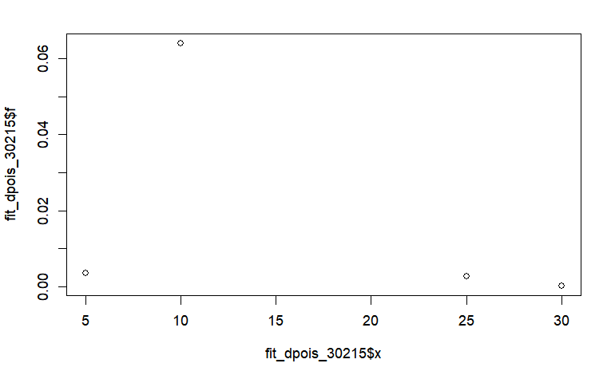

```r
plot(x= fit_dpois_30215$x, y=fit_dpois_30215$f)
```

```r
#Calculating gamma distribution
gamma_w302_2015_ <- fitdistrplus::fitdist(data=w_302_2015$DURATION%>% unlist() %>% as.numeric(), "gamma", method="mle", optim.method="Nelder-Mead", weights = round(w_302_2015$WGHT_EPI))
fit_dgamma_30215 <- data.frame(f = dgamma(w_302_2015$DURATION, shape = gamma_w302_2015_$estimate[1], rate = gamma_w302_2015_$estimate[2]), x = w_302_2015$DURATION, type = "gamma")

summary(gamma_w302_2015_)
```

```
Fitting of the distribution ' gamma ' by maximum likelihood
Parameters :
```

|  | estimate | Std. Error |
| --- | --- | --- |
| shape | 1.9013155 | 0.021115673 |
| rate | 0.1346234 | 0.001709109 |

```
Loglikelihood:  -49261.58   AIC:  98527.15   BIC:  98527.04
Correlation matrix:
          shape      rate
shape 1.0000000 0.8747052
rate  0.8747052 1.0000000
```

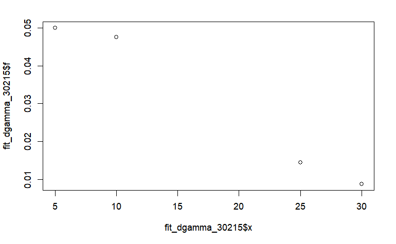

```r
plot(x= fit_dgamma_30215$x, y=fit_dgamma_30215$f)
```

```r
#Calculating exponential distribution
exp_w302_2015_ <- fitdistrplus::fitdist(data=w_302_2015$DURATION%>% unlist() %>% as.numeric(), "exp", method="mle", optim.method="Nelder-Mead", weights = round(w_302_2015$WGHT_EPI))
summary(exp_w302_2015_)
```

```
Fitting of the distribution ' exp ' by maximum likelihood
Parameters :
```

|  | estimate | Std. Error |
| --- | --- | --- |
| rate | 0.07078993 | 0.0006005069 |

```
Loglikelihood:  -50673.6   AIC:  101349.2   BIC:  101349.1
```

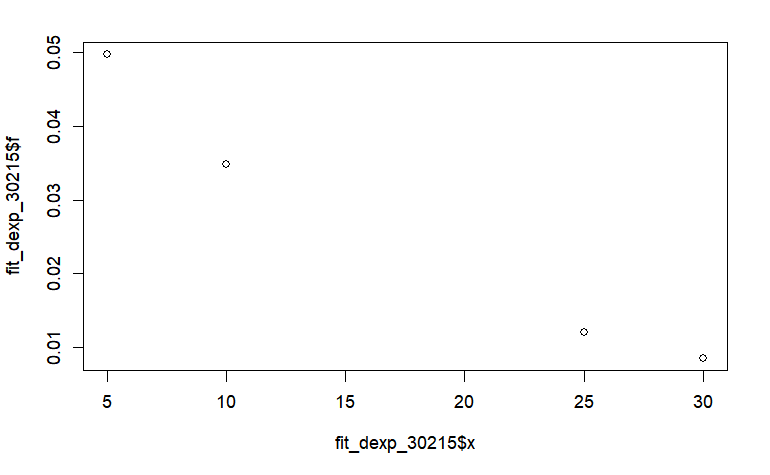

```r
rate_estimate <- exp_w302_2015_$estimate[1]

fit_dexp_30215 <- data.frame(f = dexp(w_302_2015$DURATION, rate = rate_estimate), x = w_302_2015$DURATION, type = "exp")

plot(x = fit_dexp_30215$x, y = fit_dexp_30215$f)
```

Now let’s compare these models AIC and BIC to see which fits the walk data best:

```r
#comparing these models AIC and BIC to see which fits the walk data best:
broom::glance(MASS::fitdistr(w_302_2015$DURATION%>% unlist() %>% as.numeric(),"exponential"))
```

| logLik | AIC | BIC | nobs |
| --- | --- | --- | --- |
| -24.8773 | 51.75459 | 51.7005 | 7 |

```r
broom::glance(MASS::fitdistr(w_302_2015$DURATION%>% unlist() %>% as.numeric(),"poisson"))
```

| logLik | AIC | BIC | nobs |
| --- | --- | --- | --- |
| -37.38219 | 76.76437 | 76.71028 | 7 |

```r
broom::glance(MASS::fitdistr(w_302_2015$DURATION%>% unlist() %>% as.numeric(),"gamma"))
```

| logLik | AIC | BIC | nobs |
| --- | --- | --- | --- |
| -23.99459 | 51.98917 | 51.88099 | 7 |

```r
walking_30215_exp <- exp_w302_2015_
w_302_2015 <- w_302_2015 %>%
 mutate(f_302 = dexp(DURATION, walking_30215_exp$estimate["rate"]))
summary(w_302_2015$f_302)
```

```
    Min.  1st Qu.   Median     Mean  3rd Qu.     Max.
0.008466 0.023469 0.034877 0.034192 0.049688 0.049688
```

###Destination : At someone else’s home or property (303) using a skew vs. kurtois graph to descriptive statistics of data

```
summary statistics
------
min:  5   max:  80
median:  10
mean:  14.16667
estimated sd:  12.72233
estimated skewness:  2.551557
estimated kurtosis:  10.66391
```

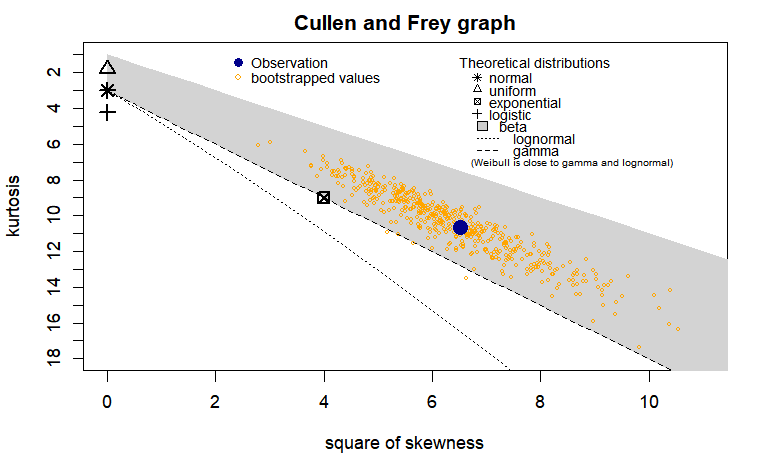

```r
# creating a skew vs. kurtois graph for walking 2015

# Filter the data based on the "destination" column
 w_303_2015 <- walking_2015 %>%
  filter(destination == "303")
descdist(w_303_2015$DURATION %>% unlist() %>% as.numeric(), discrete=FALSE, boot=500)
```

As shown in the Cullen and Frey graph, we see that gamma, weibull and exponential will likely be the best fit according to the graph above. Then we compare these models to find the best model.

```r
# Based on the skew vs. kurtois graph the best distribution

#Calculating gamma distribution

gamma_w303_2015_ <- fitdistrplus::fitdist(data=w_303_2015$DURATION%>% unlist() %>% as.numeric(), "gamma", method="mle", optim.method="Nelder-Mead", weights = round(w_303_2015$WGHT_EPI))
fit_dgamma_30315 <- data.frame(f = dgamma(w_303_2015$DURATION, shape = gamma_w303_2015_$estimate[1], rate = gamma_w303_2015_$estimate[2]), x = w_303_2015$DURATION, type = "Gamma")

summary(gamma_w303_2015_)
```

```
Fitting of the distribution ' gamma ' by maximum likelihood
Parameters :
```

|  | estimate | Std. Error |
| --- | --- | --- |
| shape | 1.9652776 | 0.0042696532 |
| rate | 0.1304716 | 0.0003226285 |

```
Loglikelihood:  -1312753   AIC:  2625510   BIC:  2625516
Correlation matrix:
          shape      rate
shape 1.0000000 0.8784951
rate  0.8784951 1.0000000
```

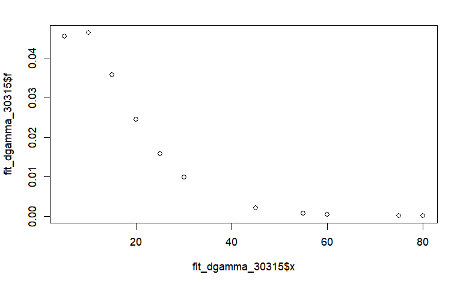

```r
plot(x= fit_dgamma_30315$x, y=fit_dgamma_30315$f)
```

```r
#Calculating weibull distribution
weibull_w303_2015_ <- fitdistrplus::fitdist(data=w_303_2015$DURATION%>% unlist() %>% as.numeric(), "weibull", method="mle", optim.method="Nelder-Mead", weights = round(w_303_2015$WGHT_EPI))
summary(weibull_w303_2015_)
```

```
Fitting of the distribution ' weibull ' by maximum likelihood
Parameters :
```

|  | estimate | Std. Error |
| --- | --- | --- |
| shape | 1.282821 | 0.001461253 |
| scale | 16.479979 | 0.022655426 |

```
Loglikelihood:  -1332882   AIC:  2665768   BIC:  2665775
Correlation matrix:
          shape     scale
shape 1.0000000 0.3431691
scale 0.3431691 1.0000000
```

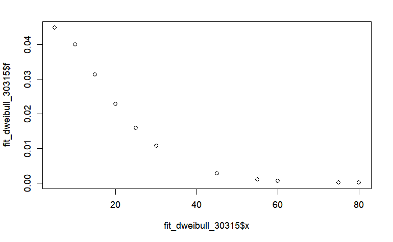

```r
fit_dweibull_30315 <- data.frame(f = dweibull(w_303_2015$DURATION, shape = weibull_w303_2015_$estimate[1], scale = weibull_w303_2015_$estimate[2]), x = w_303_2015$DURATION, type = "weibull")

plot(x= fit_dweibull_30315$x, y=fit_dweibull_30315$f)
```

```r
#Calculating exponential distribution
exp_w303_2015_ <- fitdistrplus::fitdist(data=w_303_2015$DURATION%>% unlist() %>% as.numeric(), "exp", method="mle", optim.method="Nelder-Mead", weights = round(w_303_2015$WGHT_EPI))
summary(exp_w303_2015_)
```

```
Fitting of the distribution ' exp ' by maximum likelihood
Parameters :
```

|  | estimate | Std. Error |
| --- | --- | --- |
| rate | 0.06639706 | 0.0001099453 |

```
Loglikelihood:  -1353212   AIC:  2706425   BIC:  2706429
```

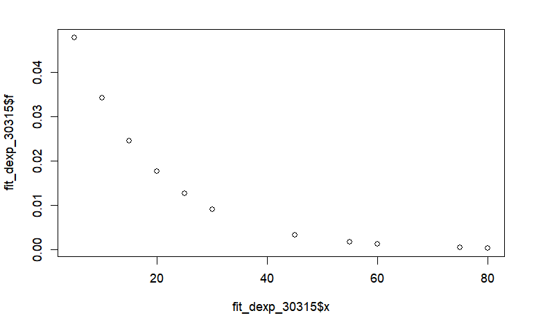

```r
fit_dexp_30315 <- data.frame(f = dexp(w_303_2015$DURATION, rate = exp_w303_2015_$estimate[1]),
                       x = w_303_2015$DURATION, type = "exp")

plot(x = fit_dexp_30315$x, y = fit_dexp_30315$f)
```

Now let’s compare these models AIC and BIC to see which fits the walk data best:

```r
#comparing these models AIC and BIC to see which fits the walk data best:
broom::glance(MASS::fitdistr(w_303_2015$DURATION%>% unlist() %>% as.numeric(),"gamma"))
```

| logLik | AIC | BIC | nobs |
| --- | --- | --- | --- |
| -805.124 | 1614.248 | 1621.107 | 228 |

```r
broom::glance(MASS::fitdistr(w_303_2015$DURATION%>% unlist() %>% as.numeric(),"weibull"))
```

| logLik | AIC | BIC | nobs |
| --- | --- | --- | --- |
| -817.0636 | 1638.127 | 1644.986 | 228 |

```r
broom::glance(MASS::fitdistr(w_303_2015$DURATION%>% unlist() %>% as.numeric(),"exponential"))
```

| logLik | AIC | BIC | nobs |
| --- | --- | --- | --- |
| -832.4033 | 1666.807 | 1670.236 | 228 |

So, gamma has largest logLik and the smallest AIC and BIC. we will pick gamma function for walking trips in 2015!(303)

```r
walking_30315_gamma <- gamma_w303_2015_
w_303_2015 <- w_303_2015 %>%
 mutate(f_303 = dgamma(DURATION, walking_30315_gamma$estimate["shape"], walking_30315_gamma$estimate["rate"]))
summary(w_303_2015$f_303)
```

```
     Min.   1st Qu.    Median      Mean   3rd Qu.      Max.
3.732e-05 3.575e-02 4.564e-02 3.739e-02 4.641e-02 4.641e-02
```

###Destination : Outdoors (305) using a skew vs. kurtois graph to descriptive statistics of data

```
summary statistics
------
min:  5   max:  80
median:  10
mean:  16.92308
estimated sd:  14.42931
estimated skewness:  2.580432
estimated kurtosis:  10.42487
```

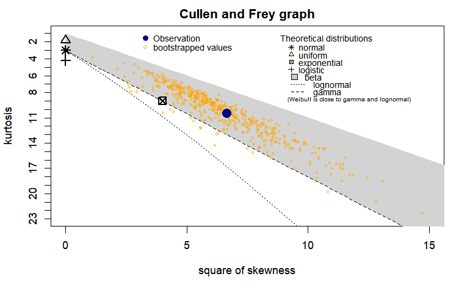

```r
# creating a skew vs. kurtois graph for walking 2015

# Filter the data based on the "destination" column
 w_305_2015 <- walking_2015 %>%
  filter(destination == "305")
descdist(w_305_2015$DURATION %>% unlist() %>% as.numeric(), discrete=FALSE, boot=500)
```

As shown in the Cullen and Frey graph, we see that gamma, poisson, weibull and exponential will likely be the best fit according to the graph above. Then we compare these models to find the best model.

```r
# Based on the skew vs. kurtois graph the best distribution

#Calculating gamma distribution

gamma_w305_2015_ <- fitdistrplus::fitdist(data=w_305_2015$DURATION%>% unlist() %>% as.numeric(), "gamma", method="mle", optim.method="Nelder-Mead", weights = round(w_305_2015$WGHT_EPI))
fit_dgamma_30515 <- data.frame(f = dgamma(w_305_2015$DURATION, shape = gamma_w305_2015_$estimate[1], rate = gamma_w305_2015_$estimate[2]), x = w_305_2015$DURATION, type = "Gamma")

summary(gamma_w305_2015_)
```

```
Fitting of the distribution ' gamma ' by maximum likelihood
Parameters :
```

|  | estimate | Std. Error |
| --- | --- | --- |
| shape | 2.0207871 | 0.0061817161 |
| rate | 0.1166746 | 0.0004047995 |

```
Loglikelihood:  -688767.1   AIC:  1377538   BIC:  1377543
Correlation matrix:
          shape      rate
shape 1.0000000 0.8816003
rate  0.8816003 1.0000000
```

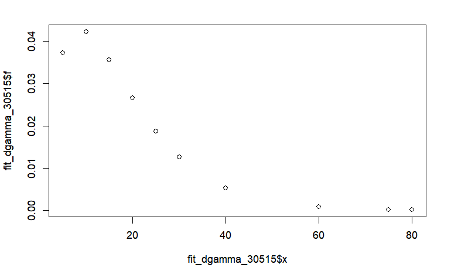

```r
plot(x= fit_dgamma_30515$x, y=fit_dgamma_30515$f)
```

```r
#Calculating exponential distribution
exp_w305_2015_ <- fitdistrplus::fitdist(data=w_305_2015$DURATION%>% unlist() %>% as.numeric(), "exp", method="mle", optim.method="Nelder-Mead", weights = round(w_305_2015$WGHT_EPI))
summary(exp_w305_2015_)
```

```
Fitting of the distribution ' exp ' by maximum likelihood
Parameters :
```

|  | estimate | Std. Error |
| --- | --- | --- |
| rate | 0.05775213 | 0.0001344103 |

```
Loglikelihood:  -710705.6   AIC:  1421413   BIC:  1421416
```

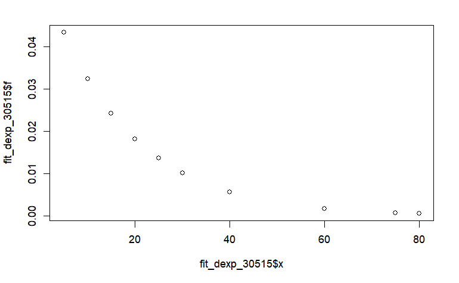

```r
fit_dexp_30515 <- data.frame(f = dexp(w_305_2015$DURATION, rate = exp_w305_2015_$estimate[1]),
                       x = w_305_2015$DURATION, type = "exp")

plot(x = fit_dexp_30515$x, y = fit_dexp_30515$f)
```

```r
#Calculating pois distribution
pois_w305_2015_ <- fitdistrplus::fitdist(data=w_305_2015$DURATION%>% unlist() %>% as.numeric(), "pois", method="mle", optim.method="Nelder-Mead", weights = round(w_305_2015$WGHT_EPI))
fit_dpois_30515 <- data.frame(f = dpois(w_305_2015$DURATION, lambda = pois_w305_2015_$estimate[1]), x = w_305_2015$DURATION, type = "pois")

summary(pois_w305_2015_)
```

```
Fitting of the distribution ' pois ' by maximum likelihood
Parameters :
```

|  | estimate | Std. Error |
| --- | --- | --- |
| lambda | 17.31971 | 0.009688244 |

```
Loglikelihood:  -1365071   AIC:  2730144   BIC:  2730147
```

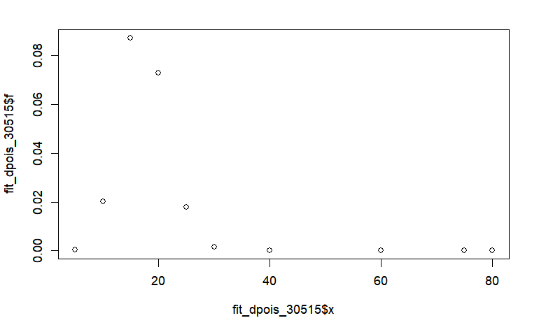

```r
plot(x= fit_dpois_30515$x, y=fit_dpois_30515$f)
```

```r
#Calculating weibull distribution
weibull_w305_2015_ <- fitdistrplus::fitdist(data=w_305_2015$DURATION%>% unlist() %>% as.numeric(), "weibull", method="mle", optim.method="Nelder-Mead", weights = round(w_305_2015$WGHT_EPI))
fit_dweibull_30515 <- data.frame(f = dweibull(w_305_2015$DURATION, shape = weibull_w305_2015_$estimate[1], scale = weibull_w305_2015_$estimate[2]), x = w_305_2015$DURATION, type = "weibull")

summary(weibull_w305_2015_)
```

```
Fitting of the distribution ' weibull ' by maximum likelihood
Parameters :
```

|  | estimate | Std. Error |
| --- | --- | --- |
| shape | 1.308206 | 0.002108388 |
| scale | 19.022603 | 0.036036469 |

```
Loglikelihood:  -698991   AIC:  1397986   BIC:  1397991
Correlation matrix:
          shape     scale
shape 1.0000000 0.3432528
scale 0.3432528 1.0000000
```

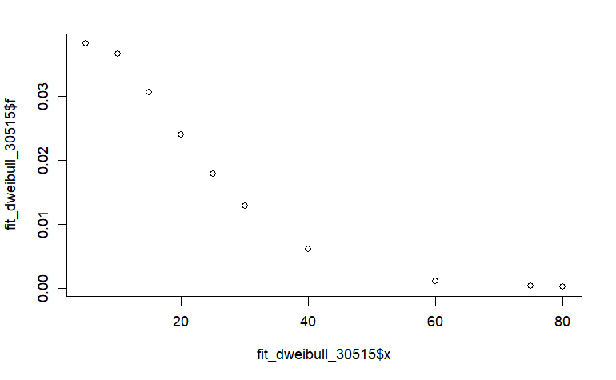

```r
plot(x= fit_dweibull_30515$x, y=fit_dweibull_30515$f)
```

Now let’s compare these models AIC and BIC to see which fits the walk data best:

```r
#comparing these models AIC and BIC to see which fits the walk data best:
broom::glance(MASS::fitdistr(w_305_2015$DURATION%>% unlist() %>% as.numeric(),"gamma"))
```

| logLik | AIC | BIC | nobs |
| --- | --- | --- | --- |
| -334.6782 | 673.3564 | 678.3782 | 91 |

```r
broom::glance(MASS::fitdistr(w_305_2015$DURATION%>% unlist() %>% as.numeric(),"poisson"))
```

| logLik | AIC | BIC | nobs |
| --- | --- | --- | --- |
| -606.3786 | 1214.757 | 1217.268 | 91 |

```r
broom::glance(MASS::fitdistr(w_305_2015$DURATION%>% unlist() %>% as.numeric(),"weibull"))
```

| logLik | AIC | BIC | nobs |
| --- | --- | --- | --- |
| -340.1649 | 684.3297 | 689.3515 | 91 |

```r
broom::glance(MASS::fitdistr(w_305_2015$DURATION%>% unlist() %>% as.numeric(),"exponential"))
```

| logLik | AIC | BIC | nobs |
| --- | --- | --- | --- |
| -348.4097 | 698.8194 | 701.3303 | 91 |

So, gamma has largest logLik and the smallest AIC and BIC. we will pick gamma function for walking trips in 2015!(305)

```r
walking_30515_gamma <- gamma_w305_2015_
w_305_2015 <- w_305_2015 %>%
 mutate(f_305 = dgamma(DURATION, walking_30515_gamma$estimate["shape"], walking_30515_gamma$estimate["rate"]))
summary(w_305_2015$f_305)
```

```
     Min.   1st Qu.    Median      Mean   3rd Qu.      Max.
9.992e-05 2.663e-02 3.722e-02 3.241e-02 4.215e-02 4.215e-02
```

###Destination : Grocery store, other stores or mall (306) using a skew vs. kurtois graph to descriptive statistics of data

```r
# creating a skew vs. kurtois graph for walking 2015

# Filter the data based on the "destination" column
 w_306_2015 <- walking_2015 %>%
  filter(destination == "306")
descdist(w_306_2015$DURATION %>% unlist() %>% as.numeric(), discrete=FALSE, boot=500)
```

[output not shown]

```r
# Based on the skew vs. kurtois graph the best distribution

#Calculating gamma distribution

gamma_w306_2015_ <- fitdistrplus::fitdist(data=w_306_2015$DURATION%>% unlist() %>% as.numeric(), "gamma", method="mle", optim.method="Nelder-Mead", weights = round(w_306_2015$WGHT_EPI))
fit_dgamma_30615 <- data.frame(f = dgamma(w_306_2015$DURATION, shape = gamma_w306_2015_$estimate[1], rate = gamma_w306_2015_$estimate[2]), x = w_306_2015$DURATION, type = "Gamma")

summary(gamma_w306_2015_)
```

```
Fitting of the distribution ' gamma ' by maximum likelihood
Parameters :
```

|  | estimate | Std. Error |
| --- | --- | --- |
| shape | 2.4329076 | 0.0042421168 |
| rate | 0.1569437 | 0.0003038314 |

```
Loglikelihood:  -2069092   AIC:  4138188   BIC:  4138196
Correlation matrix:
          shape      rate
shape 1.0000000 0.9006147
rate  0.9006147 1.0000000
```

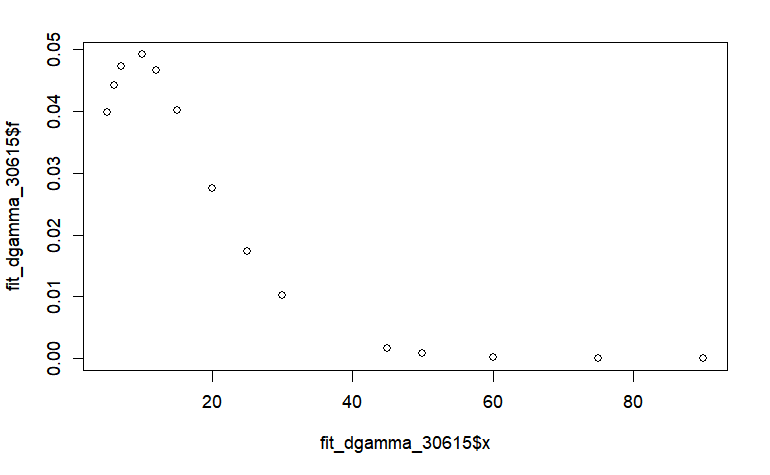

```r
plot(x= fit_dgamma_30615$x, y=fit_dgamma_30615$f)
```

```r
#Calculating exponential distribution
exp_w306_2015_ <- fitdistrplus::fitdist(data=w_306_2015$DURATION%>% unlist() %>% as.numeric(), "exp", method="mle", optim.method="Nelder-Mead", weights = round(w_306_2015$WGHT_EPI))
summary(exp_w306_2015_)
```

```
Fitting of the distribution ' exp ' by maximum likelihood
Parameters :
```

|  | estimate | Std. Error |
| --- | --- | --- |
| rate | 0.06449078 | 8.461948e-05 |

```
Loglikelihood:  -2171930   AIC:  4343863   BIC:  4343867
```

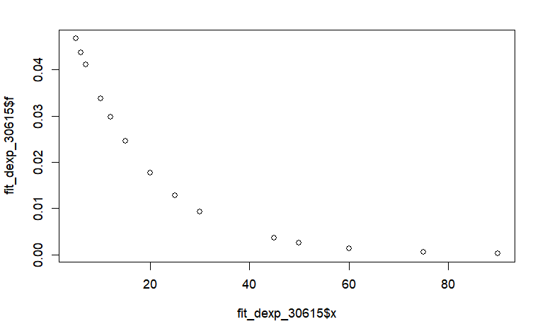

```r
fit_dexp_30615 <- data.frame(f = dexp(w_306_2015$DURATION, rate = exp_w306_2015_$estimate[1]),
                       x = w_306_2015$DURATION, type = "exp")

plot(x = fit_dexp_30615$x, y = fit_dexp_30615$f)
```

```r
#Calculating weibull distribution
weibull_w306_2015_ <- fitdistrplus::fitdist(data=w_306_2015$DURATION%>% unlist() %>% as.numeric(), "weibull", method="mle", optim.method="Nelder-Mead", weights = round(w_306_2015$WGHT_EPI))
summary(weibull_w306_2015_)
```

```
Fitting of the distribution ' weibull ' by maximum likelihood
Parameters :
```

|  | estimate | Std. Error |
| --- | --- | --- |
| shape | 1.484649 | 0.001368983 |
| scale | 17.327606 | 0.016267050 |

```
Loglikelihood:  -2100133   AIC:  4200270   BIC:  4200278
Correlation matrix:
          shape     scale
shape 1.0000000 0.3368253
scale 0.3368253 1.0000000
```

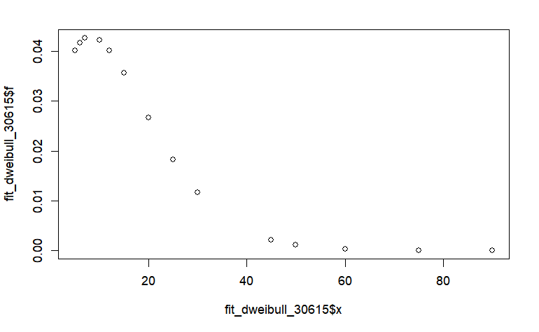

```r
fit_dweibull_30615 <- data.frame(f = dweibull(w_306_2015$DURATION, shape = weibull_w306_2015_$estimate[1], scale = weibull_w306_2015_$estimate[2]), x = w_306_2015$DURATION, type = "weibull")

plot(x= fit_dweibull_30615$x, y=fit_dweibull_30615$f)
```

Now let’s compare these models AIC and BIC to see which fits the walk data best:

```r
#comparing these models AIC and BIC to see which fits the walk data best:
broom::glance(MASS::fitdistr(w_306_2015$DURATION%>% unlist() %>% as.numeric(),"gamma"))
```

| logLik | AIC | BIC | nobs |
| --- | --- | --- | --- |
| -1261.073 | 2526.145 | 2533.89 | 355 |

```r
broom::glance(MASS::fitdistr(w_306_2015$DURATION%>% unlist() %>% as.numeric(),"weibull"))
```

| logLik | AIC | BIC | nobs |
| --- | --- | --- | --- |
| -1281.202 | 2566.404 | 2574.148 | 355 |

```r
broom::glance(MASS::fitdistr(w_306_2015$DURATION%>% unlist() %>% as.numeric(),"exponential"))
```

| logLik | AIC | BIC | nobs |
| --- | --- | --- | --- |
| -1320.994 | 2643.988 | 2647.86 | 355 |

So, gamma has largest logLik and the smallest AIC and BIC. we will pick gamma function for walking trips in 2015!(306)

```r
walking_30615_gamma <- gamma_w306_2015_
w_306_2015 <- w_306_2015 %>%
 mutate(f_306 = dgamma(DURATION, walking_30615_gamma$estimate["shape"], walking_30615_gamma$estimate["rate"]))
summary(w_306_2015$f_306)
```

```
     Min.   1st Qu.    Median      Mean   3rd Qu.      Max.
4.030e-06 2.759e-02 4.004e-02 3.664e-02 4.909e-02 4.909e-02
```

###Destination : Library, museum or theatre (307)

using a skew vs. kurtois graph to descriptive statistics of data

```r
# creating a skew vs. kurtois graph for walking 2015

# Filter the data based on the "destination" column
 w_307_2015 <- walking_2015 %>%
  filter(destination == "307")
descdist(w_307_2015$DURATION %>% unlist() %>% as.numeric(), discrete=FALSE, boot=500)
```

[output not shown]

```r
# Based on the skew vs. kurtois graph the best distribution

#Calculating gamma distribution

gamma_w307_2015_ <- fitdistrplus::fitdist(data=w_307_2015$DURATION%>% unlist() %>% as.numeric(), "gamma", method="mle", optim.method="Nelder-Mead", weights = round(w_307_2015$WGHT_EPI))
fit_dgamma_30715 <- data.frame(f = dgamma(w_307_2015$DURATION, shape = gamma_w307_2015_$estimate[1], rate = gamma_w307_2015_$estimate[2]), x = w_307_2015$DURATION, type = "Gamma")

summary(gamma_w307_2015_)
```

```
Fitting of the distribution ' gamma ' by maximum likelihood
Parameters :
```

|  | estimate | Std. Error |
| --- | --- | --- |
| shape | 6.2353915 | 0.029080892 |
| rate | 0.4329222 | 0.002102601 |

```
Loglikelihood:  -271985.6   AIC:  543975.1   BIC:  543978.8
Correlation matrix:
          shape      rate
shape 1.0000000 0.9602696
rate  0.9602696 1.0000000
```

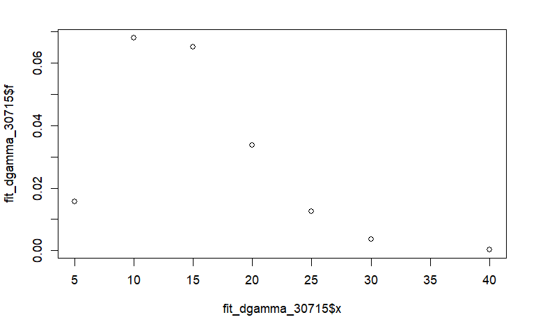

```r
plot(x= fit_dgamma_30715$x, y=fit_dgamma_30715$f)
```

```r
#Calculating weibull distribution

weibull_w307_2015_ <- fitdistrplus::fitdist(data=w_307_2015$DURATION%>% unlist() %>% as.numeric(), "weibull", method="mle", optim.method="Nelder-Mead", weights = round(w_307_2015$WGHT_EPI))
fit_dweibull_30715 <- data.frame(f = dweibull(w_307_2015$DURATION, shape = weibull_w307_2015_$estimate[1], scale = weibull_w307_2015_$estimate[2]), x = w_307_2015$DURATION, type = "weibull")

summary(weibull_w307_2015_)
```

```
Fitting of the distribution ' weibull ' by maximum likelihood
Parameters :
```

|  | estimate | Std. Error |
| --- | --- | --- |
| shape | 2.453128 | 0.005760555 |
| scale | 16.221454 | 0.023726382 |

```
Loglikelihood:  -277696.9   AIC:  555397.9   BIC:  555401.6
Correlation matrix:
          shape     scale
shape 1.0000000 0.3317082
scale 0.3317082 1.0000000
```

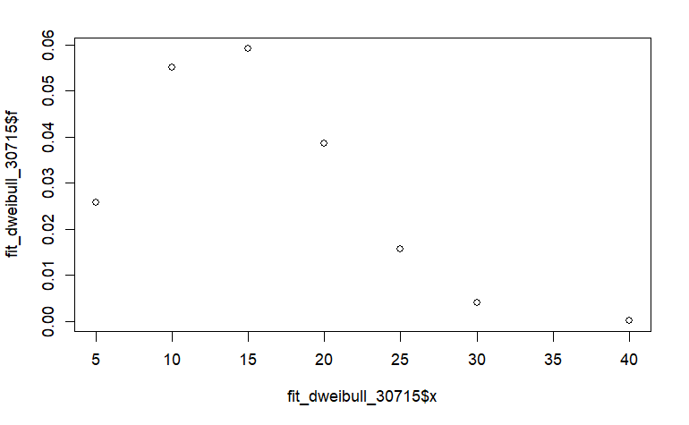

```r
plot(x= fit_dweibull_30715$x, y=fit_dweibull_30715$f)
```

```r
#Calculating lognormal distribution

lnorm_w307_2015_ <- fitdistrplus::fitdist(data=w_307_2015$DURATION%>% unlist() %>% as.numeric(), "lnorm", method="mle", optim.method="Nelder-Mead", weights = round(w_307_2015$WGHT_EPI))
fit_dlnorm_30715 <- data.frame(f = dlnorm(w_307_2015$DURATION, meanlog = lnorm_w307_2015_$estimate[1], sdlog = lnorm_w307_2015_$estimate[2]), x = w_307_2015$DURATION, type = "lnorm")

summary(lnorm_w307_2015_)
```

```
Fitting of the distribution ' lnorm ' by maximum likelihood
Parameters :
```

|  | estimate | Std. Error |
| --- | --- | --- |
| meanlog | 2.5852950 | 0.0013993595 |
| sdlog | 0.4134557 | 0.0009895177 |

```
Loglikelihood:  -272446.9   AIC:  544897.7   BIC:  544901.4
Correlation matrix:
             meanlog        sdlog
meanlog 1.0000000000 0.0002660099
sdlog   0.0002660099 1.0000000000
```

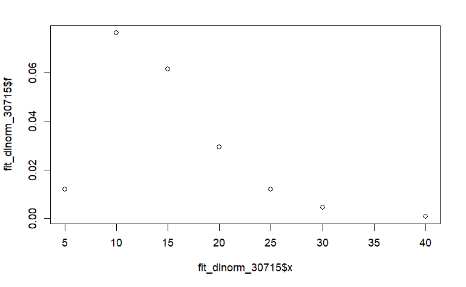

```r
plot(x= fit_dlnorm_30715$x, y=fit_dlnorm_30715$f)
```

```r
#Calculating exponential distribution
exp_w307_2015_ <- fitdistrplus::fitdist(data=w_307_2015$DURATION%>% unlist() %>% as.numeric(), "exp", method="mle", optim.method="Nelder-Mead", weights = round(w_307_2015$WGHT_EPI))
summary(exp_w307_2015_)
```

```
Fitting of the distribution ' exp ' by maximum likelihood
Parameters :
```

|  | estimate | Std. Error |
| --- | --- | --- |
| rate | 0.06941464 | 0.0002348882 |

```
Loglikelihood:  -320164.3   AIC:  640330.6   BIC:  640332.4
```

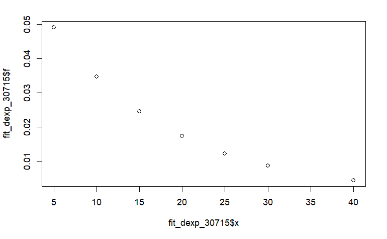

```r
fit_dexp_30715 <- data.frame(f = dexp(w_307_2015$DURATION, rate = exp_w307_2015_$estimate[1]),
                       x = w_307_2015$DURATION, type = "exp")

plot(x = fit_dexp_30715$x, y = fit_dexp_30715$f)
```

Now let’s compare these models AIC and BIC to see which fits the walk data best:

```r
#comparing these models AIC and BIC to see which fits the walk data best:
broom::glance(MASS::fitdistr(w_307_2015$DURATION%>% unlist() %>% as.numeric(),"gamma"))
```

| logLik | AIC | BIC | nobs |
| --- | --- | --- | --- |
| -155.7769 | 315.5538 | 319.2541 | 47 |

```r
broom::glance(MASS::fitdistr(w_307_2015$DURATION%>% unlist() %>% as.numeric(),"weibull"))
```

| logLik | AIC | BIC | nobs |
| --- | --- | --- | --- |
| -159.0425 | 322.0849 | 325.7852 | 47 |

```r
broom::glance(MASS::fitdistr(w_307_2015$DURATION%>% unlist() %>% as.numeric(),"lognormal"))
```

| logLik | AIC | BIC | nobs |
| --- | --- | --- | --- |
| -153.8922 | 311.7844 | 315.4847 | 47 |